# General car observation⚡

## Introduction

[figure not shown]

Speed. I am speed

This visual data story looks to explore general car observations and their key characteristics around Auckland. These observations include: the amount of car observations based on the day of the week, traffic levels based on the time of day, and the number of people in cars based on the road location. This visual story is inspired by Lightning McQueen, a fan favourite from Disney’s Cars, to make the data more engaging and enjoyable to read. Since cars and racing is something many people are familiar with and tend to enjoy, the racing-inspired design helps create a more interesting way to present my data.

## I’m a very famous race car!

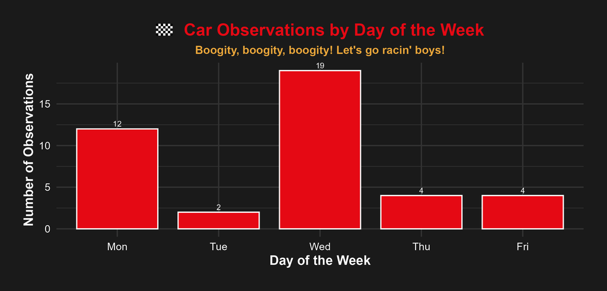

A bar chart that looks at the number of observations taken throughout the week

The first plot examines which of the seven days of the week has the highest number of recorded observations for car characteristics. Results show that weekdays has the highest observation count in comparison to weekends, which have no observations. This makes sense as I was in Taupō in the weekend and canva was down, so I was spending time with family and not on my phone. Out of the weekdays, the highest observation count was Wednesday. Weekdays give more opportunities to observe car characteristics in different locations and areas while weekends tend to be used for relaxation. This also makes sense as on Wednesday’s, I do not have class til 2 and finish around 5, leaving plenty of time to record car observations.

## Woah, what’s taking so long?

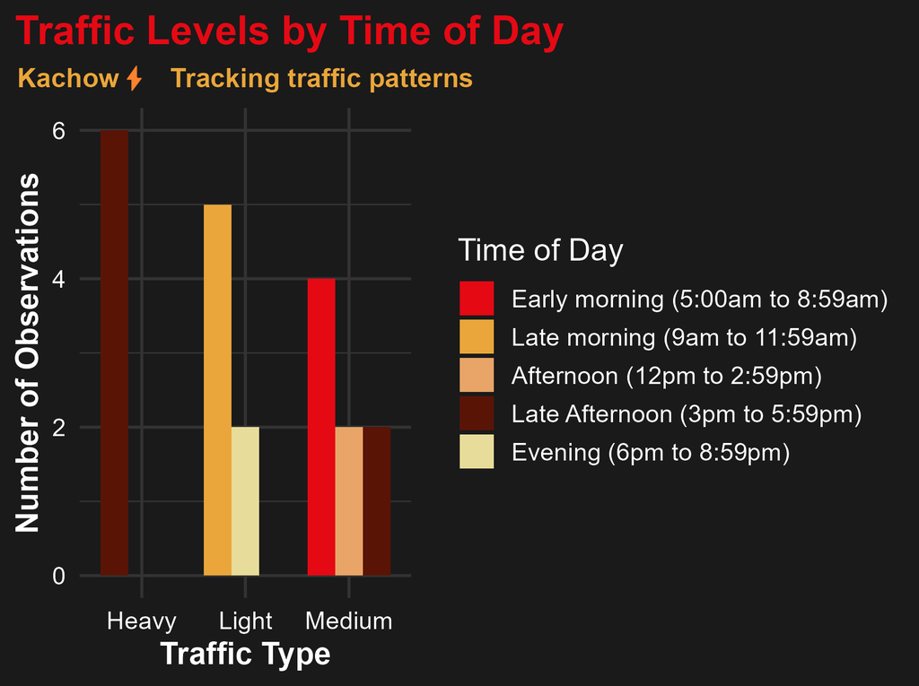

The second plot examines how time of day affects traffic levels by comparing the number of traffic observations across different periods of the day. My results show that late afternoon (3pm to 5:59pm) had the highest amount of heavy traffic. This makes sense as the late afternoon is school pick up time and when people are going home from work. Early morning (5am to 8:59am) had the highest amount of medium traffic, which makes sense because this is a busy time for both work and school commuters. In comparison, late morning (9am to 11:59am) showed the highest number of light traffic observations, suggesting that traffic begins to ease once the main morning rush has passed. The afternoon (12pm to 2:59pm) traffic was present and had medium amount of traffic, but there was a lower amount of observations; however, if we had more observations, it would likely reflect lunchtime traffic. Evening also was present with light traffic but also had a lower amount of observations.

## One winner, forty-two losers. I eat losers for breakfast

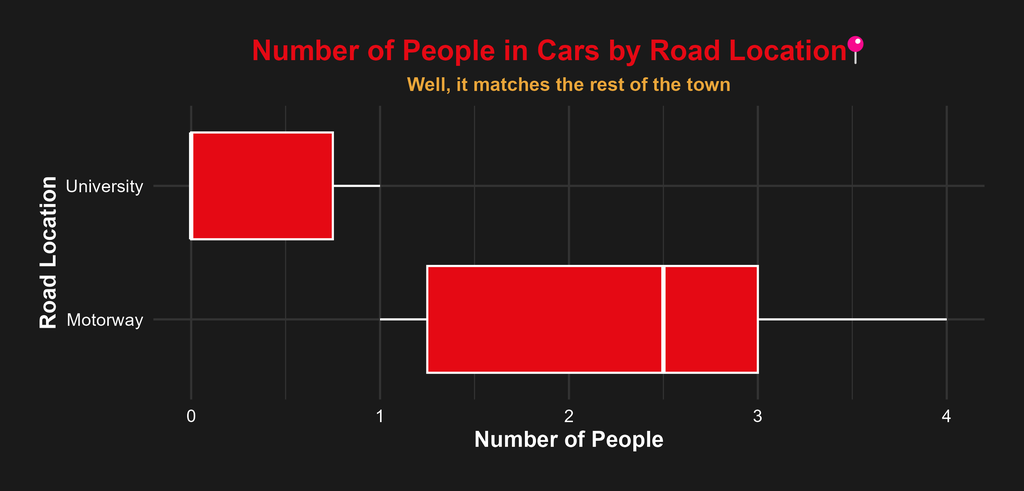